# RedemptionProject

With a little bit of magick

Jingyi Liu

2024-04-28

```css
body {
  font-family: "Alegreya", serif;
  color: #EEA920;
  font-size: 20px

}


h1 {
  font-family: "Caveat", cursive;
  font-weight: 400;
  font-style: normal;
  color: #7DB9F1;
}.
```

## Project requirements

I met the requirements by creating a GitHub repository to store all project files, ensuring version control and collaboration. On my github interface, I used bold headings, italics and sequence tables to complete my RMD, and also inserted a cute cat picture that I like into it. I also uploaded my HTML and R-markdown to my GitHub. In addition, I use GitHub Pages to host a website that showcases my projects. GitHub Pages is a platform to share my work with others. This workflow ensures project integrity, accessibility, and collaboration within the GitHub system. By leveraging these capabilities, I optimize efficiency, transparency, and quality assurance throughout the development lifecycle, ultimately delivering stronger, more successful projects. Here are the links to my GitHub repository: [https://github.com/Freyaljy/project1_report/blob/main/README.md]. This is my Github website link: https://freyaljy.github.io/project1/

[figure not shown]

[figure not shown]

```r
library(magick)
#create picture1
meme1 <- image_read("https://img.36krcdn.com/20220128/v2_b75552449b724cc584cfd7ca6c476221_img_000?x-oss-process=image/format,jpg/interlace,1")%>%
  image_scale(400)
meme1
```

[figure not shown]

```r
#create picture2
meme2 <- image_read("https://img.36krcdn.com/20220128/v2_0d2f182c015f4beea49026c58cedec63_img_000?x-oss-process=image/format,jpg/interlace,1")%>%
  image_scale(400)
meme2
```

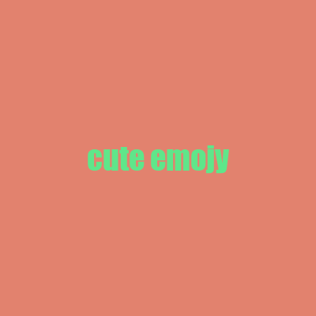

```r
#create picture3
meme3 <- image_blank(width = 400,
                     height = 400,
                     color = "#E2826E") %>%
  image_annotate(text = "cute emojy",
                 color = "#5FE68A",
                 size = 40,
                 font = "impact",
                 gravity = "center")
meme3
```

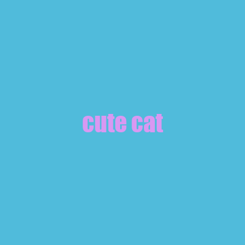

```r
#create picture4
meme4 <-image_blank(width = 400,
                    height = 400,
                    color = "#50BBDB") %>%
  image_annotate(text = "cute cat",
                 color = "#D998F2",
                 size = 40,
                 font = "Impact",
                 gravity = "center")
meme4
```

[figure not shown]

```r
#create my gif
meme5 <- c(meme1,meme3,meme2,meme4)
Final_image <- image_append(meme5)
image_write(Final_image, "my_animation.gi")
Final_image
```

[figure not shown]

```r
#Creating a animation
meme_gif <- image_animate(meme5, fps = 1)
image_write(meme_gif,"my_animation.gif")
meme_gif
```

## Learning reflection

With module1, I learned how to use R studio and create and read images in R studio to create a GIF animation. In addition, I also learned how to create R markdown, using CSS technology to change the font and color of html to make my html more refined and beautiful. We can also edit YAML to add things like subtitles and code folds. And before we can create and read the image we have to add the magick function to complete our image creation and reading. We also used R markdown to create a simple web page and published it on GitHub. In addition, I am more interested in understanding data analytics and machine learning algorithms to extract meaningful insights from complex data sets. Understanding these technologies can significantly enhance the decision-making process and drive innovation across industries.